# TimeSeries Final Project - Apple Stock Price Prediction

We use the nnfor API and the mlp function for the univariate case.

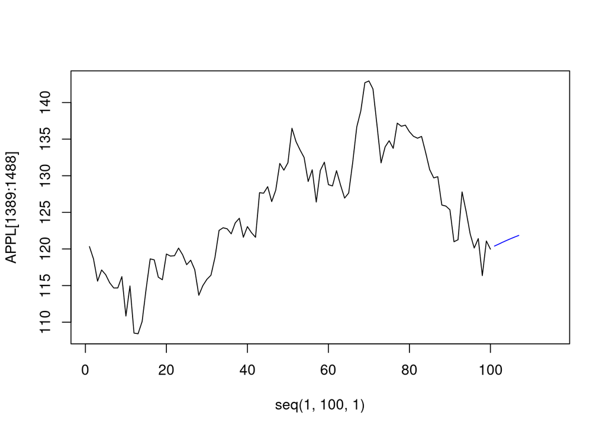

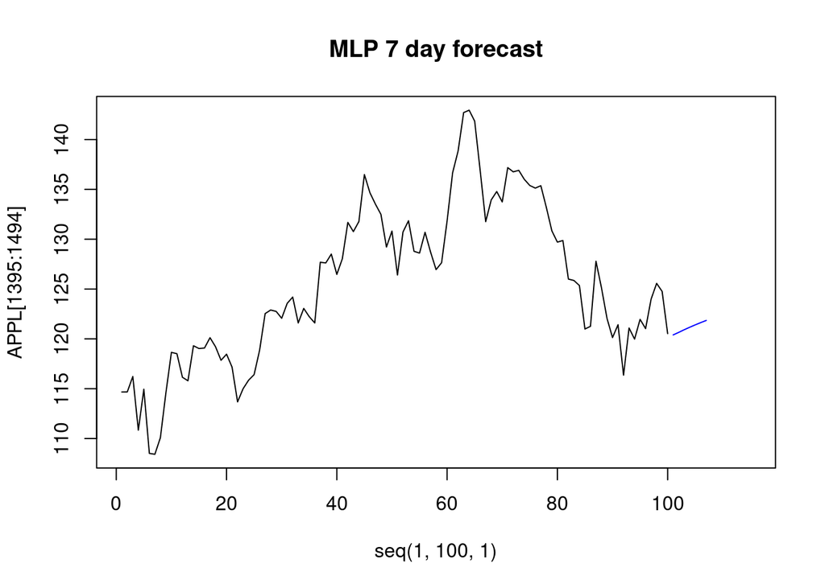

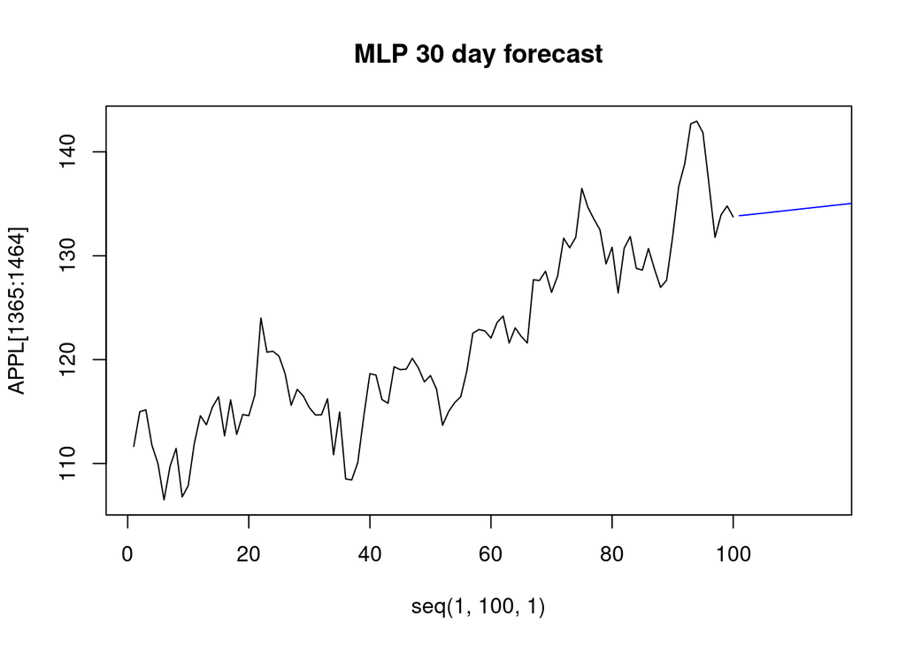

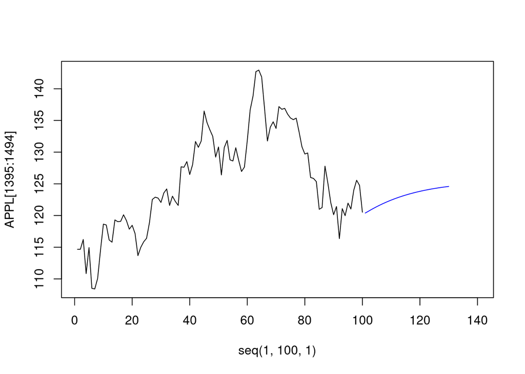

## Univariate Ensemble Model ### ARIMA + NN & SignalPlus and Neural Net

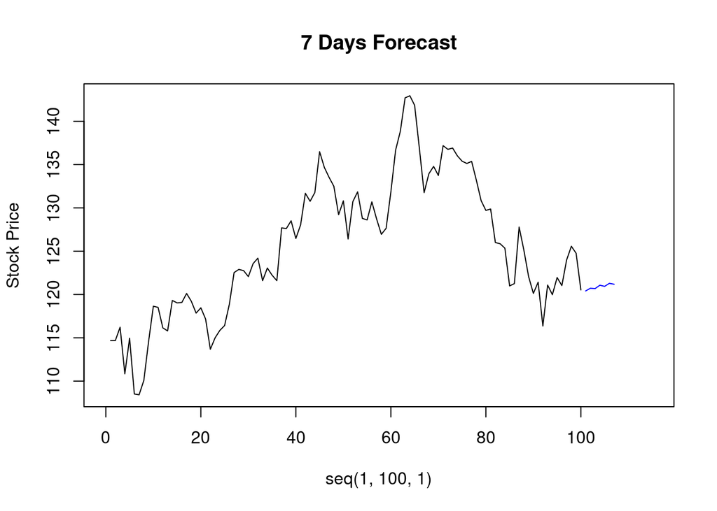

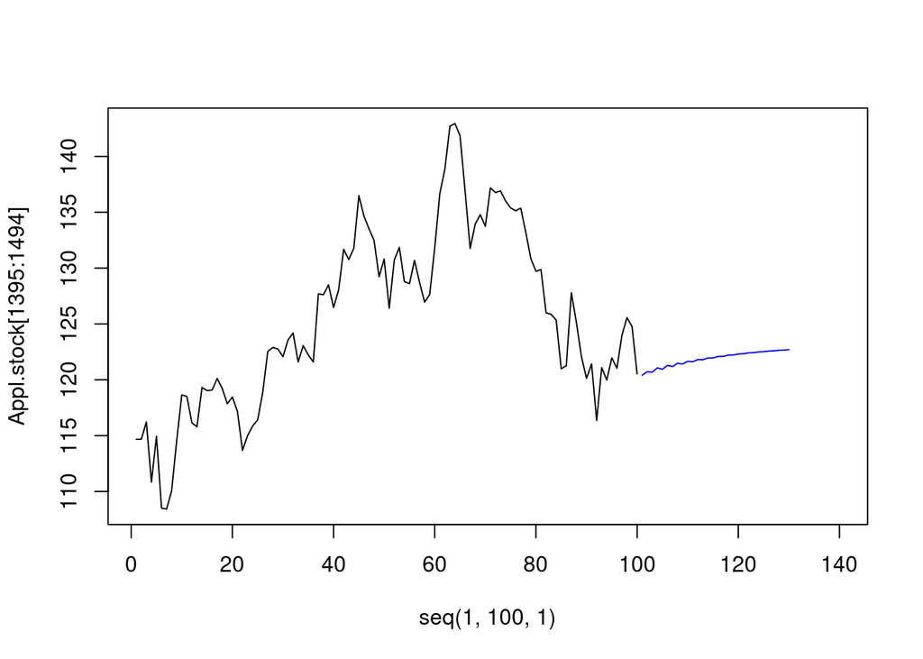

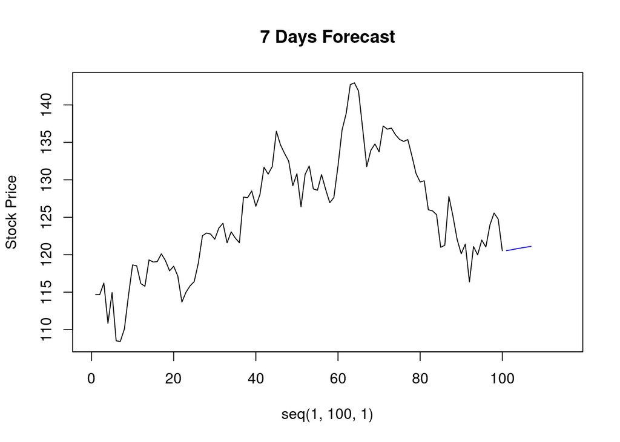

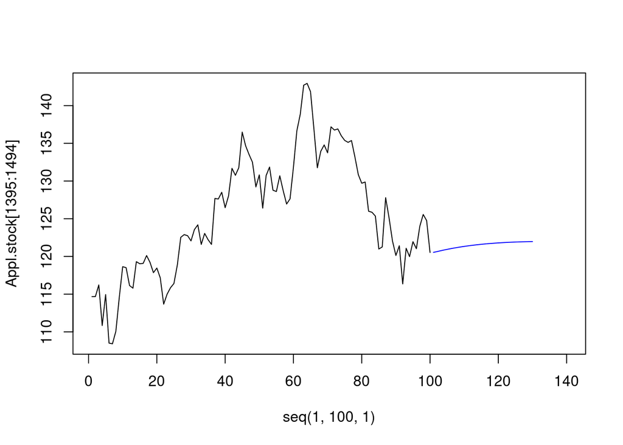

## MULTIVARIATE SECTION

### VAR AND MULTIVARIATE ARIMA MODELS

```r
knitr::opts_chunk$set(echo = TRUE)
library(tidyverse)
library(tswge)
library(vars)
library(bigtime)
apple <- read.csv("kdata/AAPL.csv")
irx <- read.csv("kdata/IRX.csv")
fvx <- read.csv("kdata/FVX.csv")
ixic <- read.csv("kdata/IXIC.csv")
```

```r
ixic$Adj.Close <- as.numeric(ixic$Adj.Close)
irx$Adj.Close <- as.numeric(irx$Adj.Close)
fvx$Adj.Close <- as.numeric(fvx$Adj.Close)
ixic2 <- drop_na(ixic, Adj.Close) %>% dplyr::select(c(Date, Adj.Close))
irx2 <- drop_na(irx, Adj.Close) %>% dplyr::select(c(Date, Adj.Close))
fvx2 <- drop_na(fvx, Adj.Close) %>% dplyr::select(c(Date, Adj.Close))
colnames(ixic2) <- c("Date", "IXIC")
colnames(irx2) <- c("Date", "IRX")
colnames(fvx2) <- c("Date", "FVX")
final = right_join(apple, irx2, by="Date")
final = right_join(final, fvx2, by="Date")
final = left_join(final, ixic2, by="Date")
final <- final %>% mutate(rel_yield = FVX/IRX)
X = final %>% dplyr::select(c(IXIC,FVX,Adj.Close,IRX))
VARselect(X, lag.max = 10, type="const")
```

```
## $selection
## AIC(n)  HQ(n)  SC(n) FPE(n)
##     10      2      2     10
##
## $criteria
##                   1            2            3            4           5
## AIC(n) -5.245879695 -5.320440099 -5.325944455 -5.332369184 -5.33692853
## HQ(n)  -5.219320212 -5.272633029 -5.256889798 -5.242066940 -5.22537870
## SC(n)  -5.174612267 -5.192158728 -5.140649142 -5.090059928 -5.03760533
## FPE(n)  0.005269185  0.004890604  0.004863764  0.004832626  0.00481066
##                   6            7            8            9           10
## AIC(n) -5.377215018 -5.403806350 -5.421180751 -5.426393437 -5.431297328
## HQ(n)  -5.244417601 -5.249761346 -5.245888161 -5.229853259 -5.213509564
## SC(n)  -5.020877876 -4.990455266 -4.950815725 -4.899014468 -4.846904416
## FPE(n)  0.004620731  0.004499511  0.004422051  0.004399112  0.004377657
```

```
##
## Call:
## lm(formula = X$Adj.Close ~ X$IXIC + X$FVX + X$IRX)
##
## Residuals:
##      Min       1Q   Median       3Q      Max
## -12.9828  -2.1135  -0.3968   1.9001  16.9353
##
## Coefficients:
##               Estimate Std. Error t value Pr(>|t|)
## (Intercept) -3.441e+01  6.401e-01 -53.762  < 2e-16 ***
## X$IXIC       1.275e-02  5.812e-05 219.352  < 2e-16 ***
## X$FVX       -1.663e+00  2.676e-01  -6.212 6.76e-10 ***
## X$IRX       -5.548e+00  2.223e-01 -24.956  < 2e-16 ***
## ---
## Signif. codes:  0 '***' 0.001 '**' 0.01 '*' 0.05 '.' 0.1 ' ' 1
##
## Residual standard error: 3.638 on 1495 degrees of freedom
## Multiple R-squared:  0.9848, Adjusted R-squared:  0.9847
## F-statistic: 3.219e+04 on 3 and 1495 DF,  p-value: < 2.2e-16
```

```
## ---------WORKING... PLEASE WAIT...
##
##
## Five Smallest Values of  aic
```

```
##       p    q        aic
## 14    4    1 -0.3889583
## 6     1    2 -0.3883740
## 10    3    0 -0.3881152
## 15    4    2 -0.3875445
## 12    3    2 -0.3871491
```

```r
arima_windowed_ASE = function(trainingSize, horizon, data) {

len = dim(data)[1]
ASEHolder = numeric()
for( i in 1:(len-(trainingSize + horizon) + 1))
{
  fit2 = arima(data[i:(i+(trainingSize-1)),3], order=c(2,1,0),xreg = data[i:(i+(trainingSize-1)),-3])
  forecast = predict(fit2,data[(trainingSize+i):(trainingSize+i+(horizon-1)),-3],n.ahead=horizon)$pred
  ASE = mean((data[(trainingSize+i):(trainingSize+ i + (horizon) - 1),3] - forecast)^2)
  ASEHolder[i] = ASE
}
  WindowedASE = mean(ASEHolder)
  return(WindowedASE)
}
#arima.7.windowedase = arima_windowed_ASE(90,7,X)
#arima.30.windowedase = arima_windowed_ASE(90,30,X)
```

```r
VAR_windowed_ASE = function(trainingSize, horizon, data, p) {

len = dim(data)[1]
ASEHolder = numeric()
for( i in 1:(len-(trainingSize + horizon) + 1))
{
  fit = VAR(data[i:(i+(trainingSize-1)),], p = p, type="const")
  forecast = predict(fit, n.ahead=horizon)$fcst$Adj.Close[,1]
  ASE = mean((data[(trainingSize+i):(trainingSize+ i + (horizon) - 1),3] - forecast)^2)

  ASEHolder[i] = ASE

}
  WindowedASE = mean(ASEHolder)
  return(WindowedASE)
}
#var.7.windowedase = VAR_windowed_ASE(90, 7, X, 10)
#var.30.windowedase = VAR_windowed_ASE(90, 30, X, 10)
```

```r
ensemble_windowed_ASE = function(trainingSize, horizon, data, p) {

len = dim(data)[1]
ASEHolder = numeric()
for( i in 1:(len-(trainingSize + horizon) + 1))
{
  fit1 = VAR(data[i:(i+(trainingSize-1)),], p = p, type="const")
  fit2 = arima(data[i:(i+(trainingSize-1)),3], order=c(4,1,2),xreg = data[i:(i+(trainingSize-1)),-3])
  forecast = (predict(fit1, n.ahead=horizon)$fcst$Adj.Close[,1] + predict(fit2,data[(trainingSize+i):(trainingSize+i+(horizon-1)),-3],n.ahead=horizon)$pred)/2
  ASE = mean((data[(trainingSize+i):(trainingSize+ i + (horizon) - 1),3] - forecast)^2)
  ASEHolder[i] = ASE
}
  WindowedASE = mean(ASEHolder)
  return(WindowedASE)
}
#ensemble.7.windowedase = ensemble_windowed_ASE(90,7,X,10)
#ensemble.30windowedase = ensemble_windowed_ASE(90,30,X,10)
```

### MULTIVARIATE MODEL USING Neural Net

we are using neuralnet API for the multivariate nn model building as we encountered issues while running this model with mlp. However, we used mlp for 7 days and 30 days forecasting for individual parameter.

## Results Table

Windowed ASEs

[output not shown]